# BAAD Stem Diameter vs Above-Ground Leaf Biomass Scaling

Interspecific, Intraspecific, Functional Group, and Family-Level Analyses

plant_scaling_data project

2026-05-12

# 1 Scope and Data Definition

This report evaluates the allometric relation between stem diameter and above-ground leaf biomass in BAAD using:

- Predictor: d.bh (m)
- Response: m.lf (kg)
- Species identifier: speciesMatched
- Family: family
- Functional group mapping from pft:
  - DA, EA -> Angiosperm
  - DG, EG -> Gymnosperm

The target relation is written as a power law:

$$m_{lf} = \alpha \cdot d_{bh}^{\beta}$$

or, in log10 space:

$$\log_{10}(m_{lf}) = \log_{10}(\alpha) + \beta \log_{10}(d_{bh})$$

A formal contrast to $\beta = 2$ is included where standard errors are available.

# 2 Filtering and Attrition

```r
kable(attrition, digits = 0, caption = "Explicit filtering attrition table")
```

Explicit filtering attrition table

| step | n_records | removed_from_previous |
| --- | --- | --- |
| Raw BAAD records | 21084 | NA |
| Non-missing d.bh and m.lf | 6465 | 14619 |
| Positive d.bh and m.lf | 6465 | 0 |
| Positive + non-missing species | 6465 | 0 |
| Positive + non-missing family | 6266 | 199 |
| Positive + mapped pft_group | 6459 | -193 |

```r
thresholds <- tibble(
  component = c(
    "Intraspecific species inclusion",
    "Intraspecific species inclusion",
    "Family inclusion",
    "Family inclusion"
  ),
  threshold = c(
    "n >= 11 individuals",
    "log10(d.bh) range >= 0.7",
    "n >= 30 individual records",
    ">= 5 species"
  )
)
kable(thresholds, caption = "Declared thresholds used in this report")
```

Declared thresholds used in this report

| component | threshold |
| --- | --- |
| Intraspecific species inclusion | n >= 11 individuals |
| Intraspecific species inclusion | log10(d.bh) range >= 0.7 |
| Family inclusion | n >= 30 individual records |
| Family inclusion | >= 5 species |

```r
kable(species_label_diagnostics, digits = 0, caption = "Species-level label consistency diagnostics")
```

Species-level label consistency diagnostics

| metric | n_species |
| --- | --- |
| Species with conflicting non-missing family labels | 3 |
| Species with conflicting non-missing pft_group labels | 1 |
| Species with any conflicting non-missing label | 4 |

# 3 Guidance Consultation and Implementation

This analysis was cross-checked against enhanced-theory and ecology-user guidance to keep modeling assumptions explicit, ecologically interpretable, and reproducible.

- Model formalism: the core model is declared as a diameter-leaf-biomass power law in raw units and log10-linearized form, with OLS and RMA estimated for complementary Model I and Model II interpretation.
- Declared thresholds: all inclusion rules are pre-declared and tabulated (intraspecific: n >= 11 and log10 diameter range >= 0.7; family: n >= 30 records and >= 5 species).
- Uncertainty and caveats: approximation limits are made explicit, including package-dependent RMA uncertainty reporting and approximate tests versus beta = 2.
- Reproducible workflow structure: setup, filtering attrition, threshold declaration, interspecific and stratified fits, diagnostics, caveats, and session metadata are organized as an auditable sequence.

# 4 Theory Framing and Testable Predictions

Leaf biomass should increase with stem diameter as an increasing power function. The exponent $\beta$ describes how rapidly foliage mass scales with stem size. A value of $\beta = 2$ implies a very steep relation where leaf mass scales approximately with area-like growth in diameter terms.

To anchor interpretation, this report estimates OLS and RMA exponents and tests whether observed slopes differ from 2 where uncertainty can be quantified.

# 5 Interspecific Analysis (Primary)

Primary interspecific inference uses species-level means in log space to reduce pseudo-replication from uneven within-species sampling.

```r
inter_df <- species_means %>%
  transmute(log_d = log_d_mean, log_mlf = log_mlf_mean)

inter_fit <- fit_scaling_models(inter_df)
inter_fit <- inter_fit %>% mutate(beta0 = 2)

kable(inter_fit, digits = 3, caption = "Interspecific (species means) OLS and RMA fits")
```

Interspecific (species means) OLS and RMA fits

| n | model | method | slope | slope_lwr | slope_upr | intercept | r2 | se | t_stat | p_beta_eq_2 | note | beta0 |
| --- | --- | --- | --- | --- | --- | --- | --- | --- | --- | --- | --- | --- |
| 351 | OLS | lm | 1.789 | 1.704 | 1.874 | 1.878 | 0.831 | 0.043 | -4.876 | 0 | NA | 2 |
| 351 | RMA | smatr::sma | 1.963 | 1.880 | 2.050 | NA | 0.831 | NA | NA | NA | RMA beta=2 p-value unavailable; interpret CI | 2 |

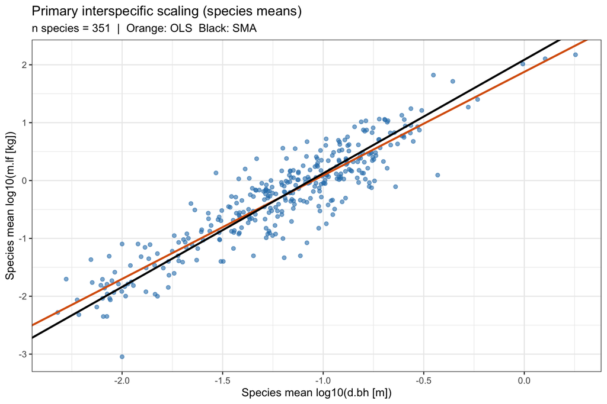

```r
# Fit SMA for the interspecific scatter overlay
if (HAS_SMATR) {
  sma_inter_sp <- tryCatch(
    smatr::sma(log_mlf_mean ~ log_d_mean, data = species_means),
    error = function(e) NULL
  )
  sma_inter_int <- if (!is.null(sma_inter_sp)) sma_inter_sp$coef[[1]][1, 1] else NA_real_
  sma_inter_sl  <- if (!is.null(sma_inter_sp)) sma_inter_sp$coef[[1]][2, 1] else NA_real_
} else {
  sma_inter_int <- NA_real_; sma_inter_sl <- NA_real_
}

ols_inter_sp  <- lm(log_mlf_mean ~ log_d_mean, data = species_means)
ols_inter_int <- coef(ols_inter_sp)[1]
ols_inter_sl  <- coef(ols_inter_sp)[2]

p_inter <- ggplot(species_means, aes(log_d_mean, log_mlf_mean)) +
  geom_point(alpha = 0.6, color = "#2c7fb8") +
  geom_abline(intercept = ols_inter_int, slope = ols_inter_sl,
              colour = "#d95f0e", linewidth = 1) +
  labs(
    x = "Species mean log10(d.bh [m])",
    y = "Species mean log10(m.lf [kg])",
    title = "Primary interspecific scaling (species means)",
    subtitle = paste0("n species = ", comma(nrow(species_means)),
                      "  |  Orange: OLS",
                      if (!is.na(sma_inter_sl)) "  Black: SMA" else "")
  )

if (!is.na(sma_inter_sl)) {
  p_inter <- p_inter +
    geom_abline(intercept = sma_inter_int, slope = sma_inter_sl,
                colour = "black", linewidth = 1)
}
print(p_inter)
```

```r
ind_fit <- fit_scaling_models(analysis_dat)
comp_tab <- bind_rows(
  inter_fit %>% mutate(context = "Species means"),
  ind_fit %>% mutate(context = "Individual records")
) %>%
  select(context, model, method, n, slope, slope_lwr, slope_upr, r2, note)

kable(comp_tab, digits = 3, caption = "Comparison: interspecific species-means vs individual-record fit")
```

Comparison: interspecific species-means vs individual-record fit

| context | model | method | n | slope | slope_lwr | slope_upr | r2 | note |
| --- | --- | --- | --- | --- | --- | --- | --- | --- |
| Species means | OLS | lm | 351 | 1.789 | 1.704 | 1.874 | 0.831 | NA |
| Species means | RMA | smatr::sma | 351 | 1.963 | 1.880 | 2.050 | 0.831 | RMA beta=2 p-value unavailable; interpret CI |
| Individual records | OLS | lm | 6465 | 1.864 | 1.845 | 1.883 | 0.854 | NA |
| Individual records | RMA | smatr::sma | 6465 | 2.017 | 1.999 | 2.036 | 0.854 | RMA beta=2 p-value unavailable; interpret CI |

# 6 Angiosperm vs Gymnosperm Split

## 6.1 Individual-level context

```r
pft_ind <- analysis_dat %>%
  filter(!is.na(pft_group)) %>%
  group_split(pft_group) %>%
  map_df(function(dg) {
    grp <- unique(dg$pft_group)[1]
    fit_scaling_models(dg) %>% mutate(group = grp, context = "Individual")
  }) %>%
  select(context, group, everything())

kable(pft_ind, digits = 3, caption = "Angiosperm vs gymnosperm fits: individual-level")
```

Angiosperm vs gymnosperm fits: individual-level

| context | group | n | model | method | slope | slope_lwr | slope_upr | intercept | r2 | se | t_stat | p_beta_eq_2 | note |
| --- | --- | --- | --- | --- | --- | --- | --- | --- | --- | --- | --- | --- | --- |
| Individual | Angiosperm | 4071 | OLS | lm | 1.828 | 1.807 | 1.849 | 1.898 | 0.880 | 0.011 | -16.259 | 0 | NA |
| Individual | Angiosperm | 4071 | RMA | smatr::sma | 1.949 | 1.928 | 1.970 | NA | 0.880 | NA | NA | NA | RMA beta=2 p-value unavailable; interpret CI |
| Individual | Gymnosperm | 2388 | OLS | lm | 1.531 | 1.499 | 1.562 | 2.006 | 0.793 | 0.016 | -29.344 | 0 | NA |
| Individual | Gymnosperm | 2388 | RMA | smatr::sma | 1.719 | 1.687 | 1.750 | NA | 0.793 | NA | NA | NA | RMA beta=2 p-value unavailable; interpret CI |

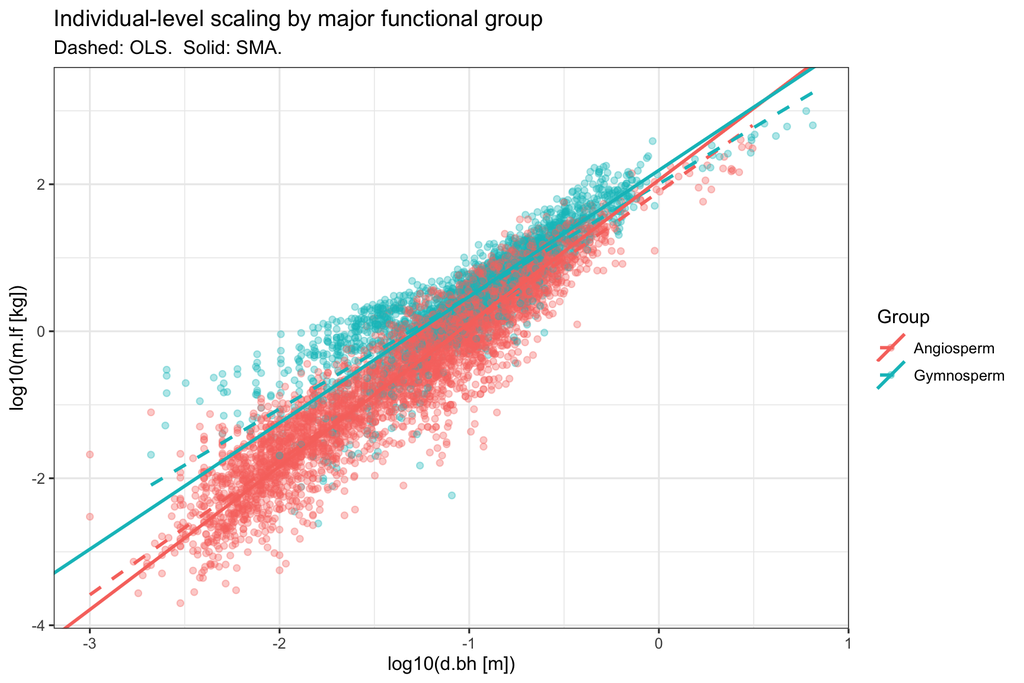

```r
# SMA lines per pft_group
pft_ind_sma <- analysis_dat %>%
  filter(!is.na(pft_group)) %>%
  group_by(pft_group) %>%
  group_modify(~ {
    tryCatch({
      fit <- if (HAS_SMATR) smatr::sma(log_mlf ~ log_d, data = .x) else NULL
      if (is.null(fit)) return(data.frame())
      data.frame(intercept = fit$coef[[1]][1, 1], slope = fit$coef[[1]][2, 1])
    }, error = function(e) data.frame())
  }) %>% ungroup()

group_colours <- c(Angiosperm = "#F8766D", Gymnosperm = "#00BFC4")

ggplot(analysis_dat %>% filter(!is.na(pft_group)), aes(log_d, log_mlf, color = pft_group)) +
  geom_point(alpha = 0.35) +
  geom_smooth(method = "lm", se = FALSE, linewidth = 1, linetype = "dashed") +
  geom_abline(data = pft_ind_sma,
              aes(intercept = intercept, slope = slope, colour = pft_group),
              linewidth = 1, linetype = "solid") +
  labs(
    x = "log10(d.bh [m])",
    y = "log10(m.lf [kg])",
    title = "Individual-level scaling by major functional group",
    subtitle = "Dashed: OLS.  Solid: SMA.",
    color = "Group"
  )
```

## 6.2 Interspecific species-mean context

```r
pft_species <- species_means %>%
  filter(!is.na(pft_group)) %>%
  group_split(pft_group) %>%
  map_df(function(ds) {
    grp <- unique(ds$pft_group)[1]
    fit_scaling_models(ds %>% transmute(log_d = log_d_mean, log_mlf = log_mlf_mean)) %>%
      mutate(group = grp, context = "Species means")
  }) %>%
  select(context, group, everything())

kable(pft_species, digits = 3, caption = "Angiosperm vs gymnosperm fits: species means")
```

Angiosperm vs gymnosperm fits: species means

| context | group | n | model | method | slope | slope_lwr | slope_upr | intercept | r2 | se | t_stat | p_beta_eq_2 | note |
| --- | --- | --- | --- | --- | --- | --- | --- | --- | --- | --- | --- | --- | --- |
| Species means | Angiosperm | 318 | OLS | lm | 1.774 | 1.691 | 1.856 | 1.813 | 0.849 | 0.042 | -5.385 | 0 | NA |
| Species means | Angiosperm | 318 | RMA | smatr::sma | 1.925 | 1.844 | 2.009 | NA | 0.849 | NA | NA | NA | RMA beta=2 p-value unavailable; interpret CI |
| Species means | Gymnosperm | 32 | OLS | lm | 1.559 | 1.339 | 1.779 | 2.069 | 0.875 | 0.108 | -4.091 | 0 | NA |
| Species means | Gymnosperm | 32 | RMA | smatr::sma | 1.667 | 1.462 | 1.902 | NA | 0.875 | NA | NA | NA | RMA beta=2 p-value unavailable; interpret CI |

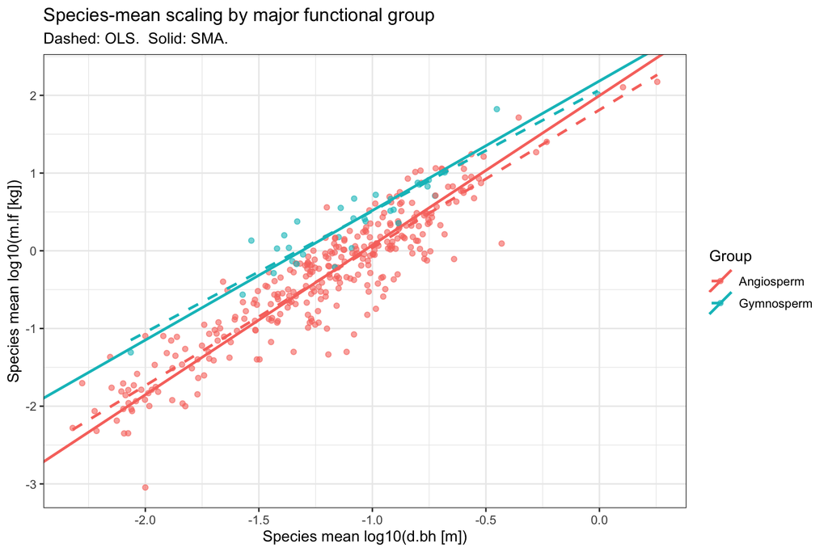

```r
# SMA lines per pft_group on species means
pft_sp_sma <- species_means %>%
  filter(!is.na(pft_group)) %>%
  group_by(pft_group) %>%
  group_modify(~ {
    tryCatch({
      fit <- if (HAS_SMATR) smatr::sma(log_mlf_mean ~ log_d_mean, data = .x) else NULL
      if (is.null(fit)) return(data.frame())
      data.frame(intercept = fit$coef[[1]][1, 1], slope = fit$coef[[1]][2, 1])
    }, error = function(e) data.frame())
  }) %>% ungroup()

ggplot(species_means %>% filter(!is.na(pft_group)), aes(log_d_mean, log_mlf_mean, color = pft_group)) +
  geom_point(alpha = 0.6) +
  geom_smooth(method = "lm", se = FALSE, linewidth = 1, linetype = "dashed") +
  geom_abline(data = pft_sp_sma,
              aes(intercept = intercept, slope = slope, colour = pft_group),
              linewidth = 1, linetype = "solid") +
  labs(
    x = "Species mean log10(d.bh [m])",
    y = "Species mean log10(m.lf [kg])",
    title = "Species-mean scaling by major functional group",
    subtitle = "Dashed: OLS.  Solid: SMA.",
    color = "Group"
  )
```

# 7 Intraspecific Scaling (Species with n >= 11 and log10 range >= 0.7)

```r
intra_screen <- analysis_dat %>%
  group_by(species) %>%
  summarise(
    n = n(),
    log_d_range = diff(range(log_d, na.rm = TRUE)),
    .groups = "drop"
  ) %>%
  left_join(species_means %>% select(species, family, pft_group), by = "species") %>%
  mutate(
    pass_n = n >= 11,
    pass_range = log_d_range >= 0.7,
    eligible = pass_n & pass_range
  )

kable(
  intra_screen %>%
    summarise(
      species_total = n(),
      species_n_ge_11 = sum(pass_n),
      species_range_ge_0_7 = sum(pass_range),
      species_eligible = sum(eligible)
    ),
  caption = "Intraspecific screening summary"
)
```

Intraspecific screening summary

| species_total | species_n_ge_11 | species_range_ge_0_7 | species_eligible |
| --- | --- | --- | --- |
| 351 | 119 | 147 | 100 |

```r
eligible_species <- intra_screen %>% filter(eligible) %>% pull(species)

intra_fits <- analysis_dat %>%
  filter(species %in% eligible_species) %>%
  group_by(species) %>%
  group_split() %>%
  map_df(function(ds) {
    sp <- unique(ds$species)[1]
    fit_scaling_models(ds) %>%
      mutate(species = sp)
  }) %>%
  left_join(species_means %>% select(species, family, pft_group), by = "species") %>%
  relocate(species, family, pft_group, model)

kable(
  intra_fits %>% arrange(desc(n), species, model),
  digits = 3,
  caption = "Per-species intraspecific OLS and RMA fits"
)
```

Per-species intraspecific OLS and RMA fits

| species | family | pft_group | model | n | method | slope | slope_lwr | slope_upr | intercept | r2 | se | t_stat | p_beta_eq_2 | note |
| --- | --- | --- | --- | --- | --- | --- | --- | --- | --- | --- | --- | --- | --- | --- |
| Pinus sylvestris | Pinaceae | Gymnosperm | OLS | 288 | lm | 1.655 | 1.540 | 1.771 | 2.037 | 0.736 | 0.059 | -5.881 | 0.000 | NA |
| Pinus sylvestris | Pinaceae | Gymnosperm | RMA | 288 | smatr::sma | 1.929 | 1.817 | 2.048 | NA | 0.736 | NA | NA | NA | RMA beta=2 p-value unavailable; interpret CI |
| Pinus taeda | Pinaceae | Gymnosperm | OLS | 276 | lm | 0.929 | 0.857 | 1.002 | 1.423 | 0.698 | 0.037 | -28.977 | 0.000 | NA |
| Pinus taeda | Pinaceae | Gymnosperm | RMA | 276 | smatr::sma | 1.113 | 1.042 | 1.188 | NA | 0.698 | NA | NA | NA | RMA beta=2 p-value unavailable; interpret CI |
| Picea abies | Pinaceae | Gymnosperm | OLS | 218 | lm | 1.444 | 1.355 | 1.533 | 2.031 | 0.826 | 0.045 | -12.300 | 0.000 | NA |
| Picea abies | Pinaceae | Gymnosperm | RMA | 218 | smatr::sma | 1.590 | 1.503 | 1.681 | NA | 0.826 | NA | NA | NA | RMA beta=2 p-value unavailable; interpret CI |
| Eucalyptus urophylla * Eucalyptus grandis (clone) | Myrtaceae | Angiosperm | OLS | 211 | lm | 1.600 | 1.400 | 1.800 | 1.903 | 0.544 | 0.101 | -3.946 | 0.000 | NA |
| Eucalyptus urophylla * Eucalyptus grandis (clone) | Myrtaceae | Angiosperm | RMA | 211 | smatr::sma | 2.170 | 1.979 | 2.379 | NA | 0.544 | NA | NA | NA | RMA beta=2 p-value unavailable; interpret CI |
| Cryptomeria japonica | Taxodiaceae | Gymnosperm | OLS | 178 | lm | 1.847 | 1.734 | 1.960 | 2.267 | 0.856 | 0.057 | -2.683 | 0.008 | NA |
| Cryptomeria japonica | Taxodiaceae | Gymnosperm | RMA | 178 | smatr::sma | 1.996 | 1.887 | 2.112 | NA | 0.856 | NA | NA | NA | RMA beta=2 p-value unavailable; interpret CI |
| Eucalyptus grandis | Myrtaceae | Angiosperm | OLS | 168 | lm | 1.266 | 1.100 | 1.432 | 1.568 | 0.577 | 0.084 | -8.729 | 0.000 | NA |
| Eucalyptus grandis | Myrtaceae | Angiosperm | RMA | 168 | smatr::sma | 1.666 | 1.509 | 1.841 | NA | 0.577 | NA | NA | NA | RMA beta=2 p-value unavailable; interpret CI |
| Toxicodendron trichocarpum | Anacardiaceae | Angiosperm | OLS | 166 | lm | 1.970 | 1.804 | 2.137 | 1.775 | 0.770 | 0.084 | -0.351 | 0.726 | NA |
| Toxicodendron trichocarpum | Anacardiaceae | Angiosperm | RMA | 166 | smatr::sma | 2.246 | 2.086 | 2.418 | NA | 0.770 | NA | NA | NA | RMA beta=2 p-value unavailable; interpret CI |
| Pinus contorta | Pinaceae | Gymnosperm | OLS | 161 | lm | 2.590 | 2.393 | 2.786 | 2.803 | 0.810 | 0.100 | 5.923 | 0.000 | NA |
| Pinus contorta | Pinaceae | Gymnosperm | RMA | 161 | smatr::sma | 2.878 | 2.688 | 3.082 | NA | 0.810 | NA | NA | NA | RMA beta=2 p-value unavailable; interpret CI |
| Pinus densiflora | Pinaceae | Gymnosperm | OLS | 153 | lm | 2.014 | 1.918 | 2.110 | 2.230 | 0.919 | 0.049 | 0.283 | 0.778 | NA |
| Pinus densiflora | Pinaceae | Gymnosperm | RMA | 153 | smatr::sma | 2.100 | 2.006 | 2.198 | NA | 0.919 | NA | NA | NA | RMA beta=2 p-value unavailable; interpret CI |
| Pinus ponderosa | Pinaceae | Gymnosperm | OLS | 149 | lm | 1.763 | 1.661 | 1.865 | 2.162 | 0.887 | 0.052 | -4.577 | 0.000 | NA |
| Pinus ponderosa | Pinaceae | Gymnosperm | RMA | 149 | smatr::sma | 1.871 | 1.772 | 1.977 | NA | 0.887 | NA | NA | NA | RMA beta=2 p-value unavailable; interpret CI |
| Fagus crenata | Fagaceae | Angiosperm | OLS | 124 | lm | 1.848 | 1.762 | 1.934 | 1.838 | 0.937 | 0.043 | -3.505 | 0.001 | NA |
| Fagus crenata | Fagaceae | Angiosperm | RMA | 124 | smatr::sma | 1.909 | 1.825 | 1.997 | NA | 0.937 | NA | NA | NA | RMA beta=2 p-value unavailable; interpret CI |
| Pseudotsuga menziesii | Pinaceae | Gymnosperm | OLS | 113 | lm | 1.578 | 1.467 | 1.689 | 2.104 | 0.877 | 0.056 | -7.533 | 0.000 | NA |
| Pseudotsuga menziesii | Pinaceae | Gymnosperm | RMA | 113 | smatr::sma | 1.685 | 1.578 | 1.799 | NA | 0.877 | NA | NA | NA | RMA beta=2 p-value unavailable; interpret CI |
| Betula papyrifera | Betulaceae | Angiosperm | OLS | 108 | lm | 1.695 | 1.535 | 1.856 | 1.736 | 0.805 | 0.081 | -3.754 | 0.000 | NA |
| Betula papyrifera | Betulaceae | Angiosperm | RMA | 108 | smatr::sma | 1.890 | 1.736 | 2.058 | NA | 0.805 | NA | NA | NA | RMA beta=2 p-value unavailable; interpret CI |
| Castanopsis cuspidata | Fagaceae | Angiosperm | OLS | 106 | lm | 1.800 | 1.650 | 1.951 | 1.966 | 0.844 | 0.076 | -2.625 | 0.010 | NA |
| Castanopsis cuspidata | Fagaceae | Angiosperm | RMA | 106 | smatr::sma | 1.960 | 1.815 | 2.117 | NA | 0.844 | NA | NA | NA | RMA beta=2 p-value unavailable; interpret CI |
| Quercus serrata | Fagaceae | Angiosperm | OLS | 106 | lm | 2.108 | 1.886 | 2.330 | 2.117 | 0.773 | 0.112 | 0.967 | 0.336 | NA |
| Quercus serrata | Fagaceae | Angiosperm | RMA | 106 | smatr::sma | 2.398 | 2.186 | 2.630 | NA | 0.773 | NA | NA | NA | RMA beta=2 p-value unavailable; interpret CI |

[output cut: 170 more lines]

```r
top_species <- intra_screen %>%
  filter(eligible) %>%
  arrange(desc(n), desc(log_d_range)) %>%
  slice_head(n = 20)

kable(top_species, digits = 3, caption = "Top eligible intraspecific species by sample size")
```

Top eligible intraspecific species by sample size

| species | n | log_d_range | family | pft_group | pass_n | pass_range | eligible |
| --- | --- | --- | --- | --- | --- | --- | --- |
| Pinus sylvestris | 288 | 1.581 | Pinaceae | Gymnosperm | TRUE | TRUE | TRUE |
| Pinus taeda | 276 | 1.676 | Pinaceae | Gymnosperm | TRUE | TRUE | TRUE |
| Picea abies | 218 | 1.762 | Pinaceae | Gymnosperm | TRUE | TRUE | TRUE |
| Eucalyptus urophylla * Eucalyptus grandis (clone) | 211 | 0.859 | Myrtaceae | Angiosperm | TRUE | TRUE | TRUE |
| Cryptomeria japonica | 178 | 1.228 | Taxodiaceae | Gymnosperm | TRUE | TRUE | TRUE |
| Eucalyptus grandis | 168 | 1.148 | Myrtaceae | Angiosperm | TRUE | TRUE | TRUE |
| Toxicodendron trichocarpum | 166 | 1.207 | Anacardiaceae | Angiosperm | TRUE | TRUE | TRUE |
| Pinus contorta | 161 | 1.337 | Pinaceae | Gymnosperm | TRUE | TRUE | TRUE |
| Pinus densiflora | 153 | 1.609 | Pinaceae | Gymnosperm | TRUE | TRUE | TRUE |
| Pinus ponderosa | 149 | 2.054 | Pinaceae | Gymnosperm | TRUE | TRUE | TRUE |
| Fagus crenata | 124 | 2.445 | Fagaceae | Angiosperm | TRUE | TRUE | TRUE |
| Pseudotsuga menziesii | 113 | 1.937 | Pinaceae | Gymnosperm | TRUE | TRUE | TRUE |
| Betula papyrifera | 108 | 2.214 | Betulaceae | Angiosperm | TRUE | TRUE | TRUE |
| Castanopsis cuspidata | 106 | 2.152 | Fagaceae | Angiosperm | TRUE | TRUE | TRUE |
| Quercus serrata | 106 | 1.568 | Fagaceae | Angiosperm | TRUE | TRUE | TRUE |
| Abies sachalinensis | 104 | 2.063 | Pinaceae | NA | TRUE | TRUE | TRUE |
| Quercus myrsinaefolia | 91 | 1.655 | Fagaceae | Angiosperm | TRUE | TRUE | TRUE |
| Eurya japonica | 87 | 2.127 | Theaceae | Angiosperm | TRUE | TRUE | TRUE |
| Nothofagus antarctica | 86 | 2.619 | Fagaceae | Angiosperm | TRUE | TRUE | TRUE |
| Populus tremuloides | 81 | 2.024 | Salicaceae | Angiosperm | TRUE | TRUE | TRUE |

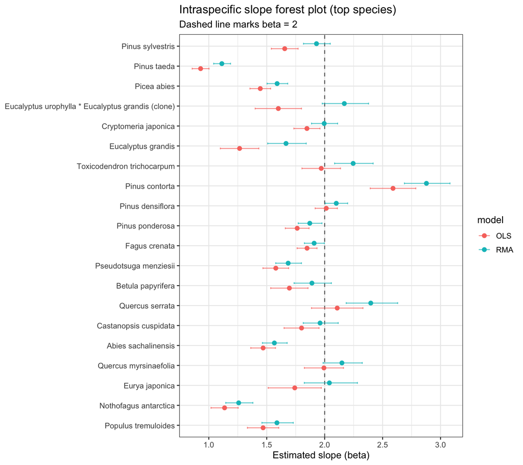

```r
forest_df <- intra_fits %>%
  filter(species %in% (top_species %>% pull(species))) %>%
  mutate(species = reorder(species, n))

ggplot(forest_df, aes(x = slope, y = species, color = model)) +
  geom_vline(xintercept = 2, linetype = "dashed", color = "gray40") +
  geom_errorbarh(aes(xmin = slope_lwr, xmax = slope_upr), height = 0.18, alpha = 0.7,
                 position = position_dodge(width = 0.5), na.rm = TRUE) +
  geom_point(size = 2.1, position = position_dodge(width = 0.5)) +
  labs(
    x = "Estimated slope (beta)",
    y = NULL,
    title = "Intraspecific slope forest plot (top species)",
    subtitle = "Dashed line marks beta = 2"
  )
```

# 8 Family-Level Analysis

Well-sampled family rule: at least 30 individual records and at least 5 species.

```r
family_screen <- analysis_dat %>%
  filter(!is.na(family), family != "") %>%
  group_by(family) %>%
  summarise(
    n_records = n(),
    n_species = n_distinct(species),
    .groups = "drop"
  ) %>%
  mutate(eligible = n_records >= 30 & n_species >= 5)

kable(family_screen %>% arrange(desc(n_records)), caption = "Family screening table", digits = 0)
```

Family screening table

| family | n_records | n_species | eligible |
| --- | --- | --- | --- |
| Pinaceae | 2000 | 25 | TRUE |
| Fagaceae | 812 | 25 | TRUE |
| Myrtaceae | 551 | 16 | TRUE |
| Betulaceae | 265 | 16 | TRUE |
| Taxodiaceae | 189 | 2 | FALSE |
| Anacardiaceae | 182 | 4 | FALSE |
| Theaceae | 158 | 7 | TRUE |
| Euphorbiaceae | 139 | 25 | TRUE |
| Cupressaceae | 136 | 5 | TRUE |
| Moraceae | 132 | 9 | TRUE |
| Malvaceae | 113 | 6 | TRUE |
| Salicaceae | 113 | 5 | TRUE |
| Aceraceae | 112 | 9 | TRUE |
| Ulmaceae | 80 | 4 | FALSE |
| Bignoniaceae | 72 | 1 | FALSE |
| Lecythidaceae | 72 | 2 | FALSE |
| Combretacea | 63 | 1 | FALSE |
| Lauraceae | 63 | 13 | TRUE |
| Violaceae | 63 | 1 | FALSE |
| Urticaceae | 62 | 1 | FALSE |
| Ericaceae | 59 | 10 | TRUE |
| Vochysiaceae | 53 | 2 | FALSE |
| Araliaceae | 51 | 5 | TRUE |
| Rubiaceae | 44 | 3 | FALSE |
| Aquifoliaceae | 42 | 6 | TRUE |
| Melastomataceae | 38 | 3 | FALSE |
| Rosaceae | 35 | 9 | TRUE |
| Fabaceae | 32 | 4 | FALSE |
| Annonaceae | 31 | 7 | TRUE |
| Dipterocarpaceae | 31 | 12 | TRUE |

[output cut: 51 more lines]

```r
eligible_families <- family_screen %>% filter(eligible) %>% pull(family)

family_fits <- analysis_dat %>%
  filter(family %in% eligible_families) %>%
  group_by(family) %>%
  group_split() %>%
  map_df(function(dfam) {
    fam <- unique(dfam$family)[1]
    fit_scaling_models(dfam) %>%
      mutate(family = fam)
  }) %>%
  left_join(family_screen, by = "family") %>%
  relocate(family, n_records, n_species, model)

kable(family_fits %>% arrange(desc(n_records), family, model), digits = 3,
      caption = "Family-level OLS and RMA fits for well-sampled families")
```

Family-level OLS and RMA fits for well-sampled families

| family | n_records | n_species | model | n | method | slope | slope_lwr | slope_upr | intercept | r2 | se | t_stat | p_beta_eq_2 | note | eligible |
| --- | --- | --- | --- | --- | --- | --- | --- | --- | --- | --- | --- | --- | --- | --- | --- |
| Pinaceae | 2000 | 25 | OLS | 2000 | lm | 1.495 | 1.458 | 1.531 | 1.951 | 0.764 | 0.019 | -27.189 | 0.000 | NA | TRUE |
| Pinaceae | 2000 | 25 | RMA | 2000 | smatr::sma | 1.710 | 1.674 | 1.747 | NA | 0.764 | NA | NA | NA | RMA beta=2 p-value unavailable; interpret CI | TRUE |
| Fagaceae | 812 | 25 | OLS | 812 | lm | 1.668 | 1.614 | 1.721 | 1.717 | 0.823 | 0.027 | -12.237 | 0.000 | NA | TRUE |
| Fagaceae | 812 | 25 | RMA | 812 | smatr::sma | 1.838 | 1.786 | 1.892 | NA | 0.823 | NA | NA | NA | RMA beta=2 p-value unavailable; interpret CI | TRUE |
| Myrtaceae | 551 | 16 | OLS | 551 | lm | 1.554 | 1.484 | 1.623 | 1.881 | 0.779 | 0.035 | -12.652 | 0.000 | NA | TRUE |
| Myrtaceae | 551 | 16 | RMA | 551 | smatr::sma | 1.760 | 1.692 | 1.831 | NA | 0.779 | NA | NA | NA | RMA beta=2 p-value unavailable; interpret CI | TRUE |
| Betulaceae | 265 | 16 | OLS | 265 | lm | 1.709 | 1.622 | 1.795 | 1.748 | 0.853 | 0.044 | -6.653 | 0.000 | NA | TRUE |
| Betulaceae | 265 | 16 | RMA | 265 | smatr::sma | 1.850 | 1.766 | 1.939 | NA | 0.853 | NA | NA | NA | RMA beta=2 p-value unavailable; interpret CI | TRUE |
| Theaceae | 158 | 7 | OLS | 158 | lm | 1.871 | 1.740 | 2.003 | 1.996 | 0.835 | 0.067 | -1.929 | 0.056 | NA | TRUE |
| Theaceae | 158 | 7 | RMA | 158 | smatr::sma | 2.048 | 1.921 | 2.184 | NA | 0.835 | NA | NA | NA | RMA beta=2 p-value unavailable; interpret CI | TRUE |
| Euphorbiaceae | 139 | 25 | OLS | 139 | lm | 1.972 | 1.876 | 2.067 | 2.099 | 0.924 | 0.048 | -0.588 | 0.558 | NA | TRUE |
| Euphorbiaceae | 139 | 25 | RMA | 139 | smatr::sma | 2.051 | 1.958 | 2.149 | NA | 0.924 | NA | NA | NA | RMA beta=2 p-value unavailable; interpret CI | TRUE |
| Cupressaceae | 136 | 5 | OLS | 136 | lm | 1.388 | 1.307 | 1.470 | 1.944 | 0.894 | 0.041 | -14.825 | 0.000 | NA | TRUE |
| Cupressaceae | 136 | 5 | RMA | 136 | smatr::sma | 1.468 | 1.389 | 1.552 | NA | 0.894 | NA | NA | NA | RMA beta=2 p-value unavailable; interpret CI | TRUE |
| Moraceae | 132 | 9 | OLS | 132 | lm | 1.831 | 1.667 | 1.995 | 1.975 | 0.789 | 0.083 | -2.039 | 0.043 | NA | TRUE |
| Moraceae | 132 | 9 | RMA | 132 | smatr::sma | 2.061 | 1.903 | 2.231 | NA | 0.789 | NA | NA | NA | RMA beta=2 p-value unavailable; interpret CI | TRUE |
| Malvaceae | 113 | 6 | OLS | 113 | lm | 1.600 | 1.448 | 1.753 | 1.392 | 0.796 | 0.077 | -5.202 | 0.000 | NA | TRUE |
| Malvaceae | 113 | 6 | RMA | 113 | smatr::sma | 1.793 | 1.648 | 1.952 | NA | 0.796 | NA | NA | NA | RMA beta=2 p-value unavailable; interpret CI | TRUE |
| Salicaceae | 113 | 5 | OLS | 113 | lm | 1.415 | 1.302 | 1.529 | 1.292 | 0.847 | 0.057 | -10.223 | 0.000 | NA | TRUE |
| Salicaceae | 113 | 5 | RMA | 113 | smatr::sma | 1.538 | 1.429 | 1.656 | NA | 0.847 | NA | NA | NA | RMA beta=2 p-value unavailable; interpret CI | TRUE |
| Aceraceae | 112 | 9 | OLS | 112 | lm | 2.041 | 1.909 | 2.173 | 2.009 | 0.895 | 0.067 | 0.612 | 0.542 | NA | TRUE |
| Aceraceae | 112 | 9 | RMA | 112 | smatr::sma | 2.158 | 2.029 | 2.294 | NA | 0.895 | NA | NA | NA | RMA beta=2 p-value unavailable; interpret CI | TRUE |
| Lauraceae | 63 | 13 | OLS | 63 | lm | 1.886 | 1.757 | 2.015 | 1.887 | 0.933 | 0.065 | -1.767 | 0.082 | NA | TRUE |
| Lauraceae | 63 | 13 | RMA | 63 | smatr::sma | 1.952 | 1.827 | 2.086 | NA | 0.933 | NA | NA | NA | RMA beta=2 p-value unavailable; interpret CI | TRUE |
| Ericaceae | 59 | 10 | OLS | 59 | lm | 1.711 | 1.529 | 1.893 | 1.685 | 0.861 | 0.091 | -3.181 | 0.002 | NA | TRUE |
| Ericaceae | 59 | 10 | RMA | 59 | smatr::sma | 1.843 | 1.670 | 2.034 | NA | 0.861 | NA | NA | NA | RMA beta=2 p-value unavailable; interpret CI | TRUE |
| Araliaceae | 51 | 5 | OLS | 51 | lm | 1.954 | 1.734 | 2.173 | 1.938 | 0.867 | 0.109 | -0.423 | 0.674 | NA | TRUE |
| Araliaceae | 51 | 5 | RMA | 51 | smatr::sma | 2.098 | 1.890 | 2.329 | NA | 0.867 | NA | NA | NA | RMA beta=2 p-value unavailable; interpret CI | TRUE |
| Aquifoliaceae | 42 | 6 | OLS | 42 | lm | 1.668 | 1.314 | 2.022 | 1.796 | 0.694 | 0.175 | -1.894 | 0.065 | NA | TRUE |
| Aquifoliaceae | 42 | 6 | RMA | 42 | smatr::sma | 2.003 | 1.680 | 2.388 | NA | 0.694 | NA | NA | NA | RMA beta=2 p-value unavailable; interpret CI | TRUE |
| Rosaceae | 35 | 9 | OLS | 35 | lm | 2.154 | 1.643 | 2.666 | 1.904 | 0.690 | 0.251 | 0.614 | 0.543 | NA | TRUE |
| Rosaceae | 35 | 9 | RMA | 35 | smatr::sma | 2.593 | 2.132 | 3.154 | NA | 0.690 | NA | NA | NA | RMA beta=2 p-value unavailable; interpret CI | TRUE |
| Annonaceae | 31 | 7 | OLS | 31 | lm | 1.749 | 1.482 | 2.017 | 1.983 | 0.861 | 0.131 | -1.919 | 0.065 | NA | TRUE |
| Annonaceae | 31 | 7 | RMA | 31 | smatr::sma | 1.886 | 1.637 | 2.172 | NA | 0.861 | NA | NA | NA | RMA beta=2 p-value unavailable; interpret CI | TRUE |
| Dipterocarpaceae | 31 | 12 | OLS | 31 | lm | 1.702 | 1.591 | 1.813 | 1.811 | 0.971 | 0.054 | -5.477 | 0.000 | NA | TRUE |
| Dipterocarpaceae | 31 | 12 | RMA | 31 | smatr::sma | 1.727 | 1.620 | 1.842 | NA | 0.971 | NA | NA | NA | RMA beta=2 p-value unavailable; interpret CI | TRUE |

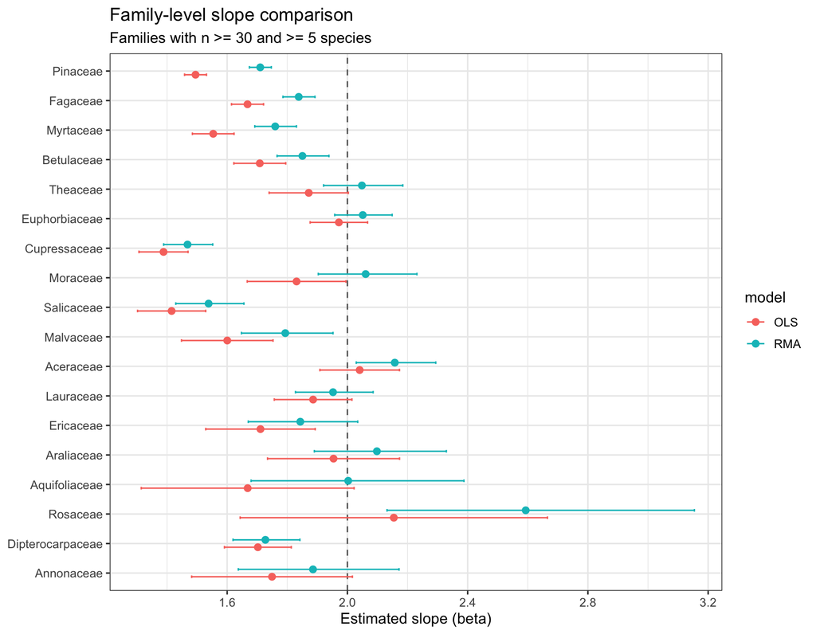

```r
ggplot(family_fits, aes(x = slope, y = reorder(family, n_records), color = model)) +
  geom_vline(xintercept = 2, linetype = "dashed", color = "gray40") +
  geom_errorbarh(aes(xmin = slope_lwr, xmax = slope_upr), height = 0.18,
                 position = position_dodge(width = 0.5), na.rm = TRUE) +
  geom_point(size = 2.2, position = position_dodge(width = 0.5)) +
  labs(
    x = "Estimated slope (beta)",
    y = NULL,
    title = "Family-level slope comparison",
    subtitle = "Families with n >= 30 and >= 5 species"
  )
```

# 9 Family-Level Exponent Distributions (Angiosperm vs Gymnosperm)

Distributions of OLS scaling exponents (slopes) across eligible families, split by major functional group. The gymnosperm family list is hardcoded from the standard classification; families not on the list are treated as angiosperms.

```r
gymno_families <- c(
  "Pinaceae","Cupressaceae","Podocarpaceae","Araucariaceae",
  "Taxaceae","Cephalotaxaceae","Sciadopityaceae","Gnetaceae",
  "Welwitschiaceae","Ephedraceae","Cycadaceae","Zamiaceae","Ginkgoaceae"
)

family_fits_ag <- family_fits %>%
  filter(model == "OLS", is.finite(slope)) %>%
  mutate(
    ag_group = if_else(family %in% gymno_families, "Gymnosperm", "Angiosperm")
  )

family_ag_counts <- family_fits_ag %>%
  count(ag_group, name = "n_families")
kable(family_ag_counts, caption = "Eligible families per major group (family exponent distribution)")
```

Eligible families per major group (family exponent distribution)

| ag_group | n_families |
| --- | --- |
| Angiosperm | 16 |
| Gymnosperm | 2 |

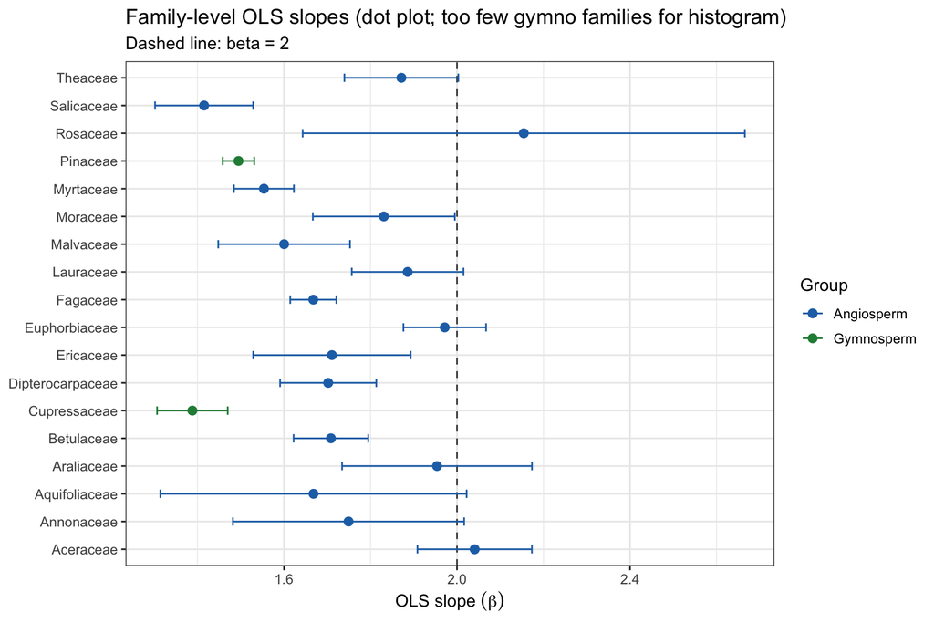

```r
n_gymno_fam <- sum(family_fits_ag$ag_group == "Gymnosperm", na.rm = TRUE)

if (n_gymno_fam >= 3) {
  ggplot(family_fits_ag, aes(x = slope, fill = ag_group)) +
    geom_histogram(bins = 12, color = "white", alpha = 0.85, position = "identity") +
    geom_vline(xintercept = 2, linetype = "dashed", color = "gray30") +
    facet_wrap(~ ag_group, ncol = 1, scales = "free_y") +
    scale_fill_manual(values = c("Angiosperm" = "#2171b5", "Gymnosperm" = "#238b45")) +
    labs(
      x = expression("Family-level OLS slope " * (beta)),
      y = "Number of families",
      title = "Family-level OLS exponent distributions: Angiosperm vs Gymnosperm",
      subtitle = "Families with n >= 30 records and >= 5 species. Dashed line: beta = 2."
    ) +
    theme(legend.position = "none")
} else {
  ggplot(family_fits_ag, aes(x = slope, y = family, color = ag_group)) +
    geom_vline(xintercept = 2, linetype = "dashed", color = "gray30") +
    geom_errorbarh(aes(xmin = slope_lwr, xmax = slope_upr), height = 0.3,
                   position = position_dodge(width = 0.5), na.rm = TRUE) +
    geom_point(size = 2.5, position = position_dodge(width = 0.5)) +
    scale_color_manual(values = c("Angiosperm" = "#2171b5", "Gymnosperm" = "#238b45")) +
    labs(
      x = expression("OLS slope " * (beta)),
      y = NULL,
      color = "Group",
      title = "Family-level OLS slopes (dot plot; too few gymno families for histogram)",
      subtitle = "Dashed line: beta = 2"
    )
}
```

```r
fam_exp_summary <- family_fits_ag %>%
  group_by(ag_group) %>%
  summarise(
    n_families    = n(),
    median_slope  = median(slope, na.rm = TRUE),
    mean_slope    = mean(slope, na.rm = TRUE),
    sd_slope      = sd(slope, na.rm = TRUE),
    q25           = quantile(slope, 0.25, na.rm = TRUE),
    q75           = quantile(slope, 0.75, na.rm = TRUE),
    .groups = "drop"
  )
kable(fam_exp_summary, digits = 3,
      caption = "Family-level OLS exponent distribution summary by major group")
```

Family-level OLS exponent distribution summary by major group

| ag_group | n_families | median_slope | mean_slope | sd_slope | q25 | q75 |
| --- | --- | --- | --- | --- | --- | --- |
| Angiosperm | 16 | 1.730 | 1.780 | 0.192 | 1.668 | 1.903 |
| Gymnosperm | 2 | 1.442 | 1.442 | 0.075 | 1.415 | 1.468 |

# 10 Intraspecific Slope Distributions (Angiosperm vs Gymnosperm)

Distribution of OLS scaling slopes across eligible intraspecific species (n >= 11, log10 diameter range >= 0.7), split by major functional group.

```r
intra_fits_ag <- intra_fits %>%
  filter(model == "OLS", is.finite(slope)) %>%
  mutate(
    ag_group = case_when(
      !is.na(pft_group) & pft_group == "Gymnosperm" ~ "Gymnosperm",
      family %in% gymno_families ~ "Gymnosperm",
      TRUE ~ "Angiosperm"
    )
  )

intra_ag_counts <- intra_fits_ag %>%
  count(ag_group, name = "n_species")
kable(intra_ag_counts, caption = "Eligible intraspecific species per major group")
```

Eligible intraspecific species per major group

| ag_group | n_species |
| --- | --- |
| Angiosperm | 73 |
| Gymnosperm | 27 |

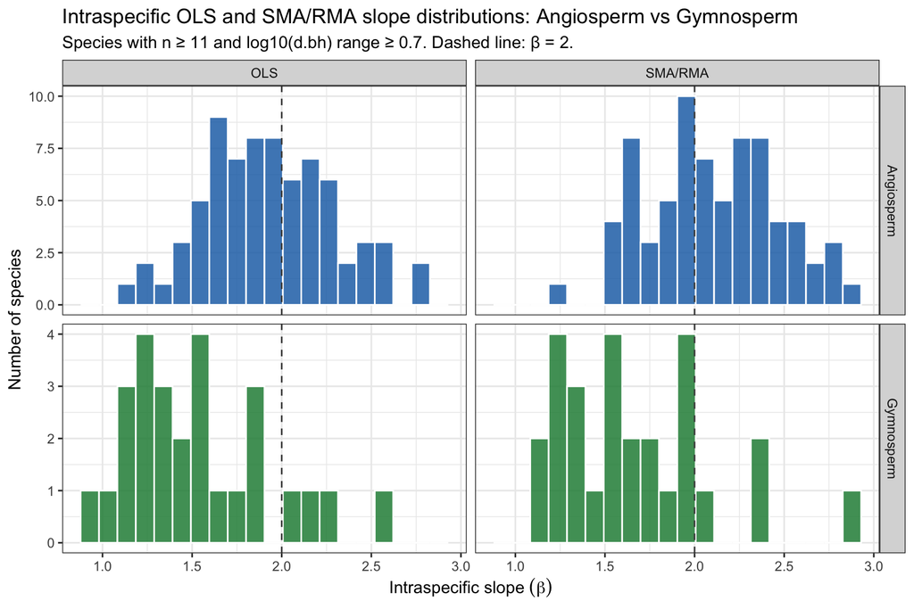

```r
# Include both OLS and RMA slopes side by side
intra_fits_both <- intra_fits %>%
  filter(is.finite(slope)) %>%
  mutate(
    ag_group = case_when(
      !is.na(pft_group) & pft_group == "Gymnosperm" ~ "Gymnosperm",
      family %in% gymno_families ~ "Gymnosperm",
      TRUE ~ "Angiosperm"
    )
  ) %>%
  select(species, model, slope, ag_group) %>%
  # Rename model labels for clarity in facets
  mutate(model = dplyr::recode(model, OLS = "OLS", RMA = "SMA/RMA"))

n_gymno_intra <- sum(intra_fits_ag$ag_group == "Gymnosperm", na.rm = TRUE)

if (n_gymno_intra >= 3) {
  ggplot(intra_fits_both, aes(x = slope, fill = ag_group)) +
    geom_histogram(bins = 20, color = "white", alpha = 0.85, position = "identity") +
    geom_vline(xintercept = 2, linetype = "dashed", color = "gray30") +
    facet_grid(ag_group ~ model, scales = "free_y") +
    scale_fill_manual(values = c("Angiosperm" = "#2171b5", "Gymnosperm" = "#238b45")) +
    labs(
      x = expression("Intraspecific slope " * (beta)),
      y = "Number of species",
      title = "Intraspecific OLS and SMA/RMA slope distributions: Angiosperm vs Gymnosperm",
      subtitle = "Species with n \u2265 11 and log10(d.bh) range \u2265 0.7. Dashed line: \u03b2 = 2."
    ) +
    theme(legend.position = "none")
} else {
  ggplot(intra_fits_both, aes(x = slope, fill = ag_group)) +
    geom_histogram(bins = 20, color = "white", alpha = 0.85) +
    geom_vline(xintercept = 2, linetype = "dashed", color = "gray30") +
    scale_fill_manual(values = c("Angiosperm" = "#2171b5", "Gymnosperm" = "#238b45")) +
    facet_wrap(~ model, ncol = 2) +
    labs(
      x = expression("Intraspecific slope " * (beta)),
      y = "Number of species",
      title = "Intraspecific OLS and SMA/RMA slope distributions (pooled; too few gymno species)",
      subtitle = "Dashed line: \u03b2 = 2"
    )
}
```

```r
intra_slope_summary <- intra_fits_ag %>%
  group_by(ag_group) %>%
  summarise(
    n_species     = n(),
    median_slope  = median(slope, na.rm = TRUE),
    mean_slope    = mean(slope, na.rm = TRUE),
    sd_slope      = sd(slope, na.rm = TRUE),
    q25           = quantile(slope, 0.25, na.rm = TRUE),
    q75           = quantile(slope, 0.75, na.rm = TRUE),
    .groups = "drop"
  )
kable(intra_slope_summary, digits = 3,
      caption = "Intraspecific OLS slope distribution summary by major group")
```

Intraspecific OLS slope distribution summary by major group

| ag_group | n_species | median_slope | mean_slope | sd_slope | q25 | q75 |
| --- | --- | --- | --- | --- | --- | --- |
| Angiosperm | 73 | 1.910 | 1.935 | 0.360 | 1.660 | 2.172 |
| Gymnosperm | 27 | 1.469 | 1.542 | 0.403 | 1.263 | 1.805 |

# 11 Phylogenetic Generalized Least Squares (PGLS)

PGLS is applied to the interspecific species-means data to account for phylogenetic non-independence across species. The phylogeny is built using V.PhyloMaker2 (Jin & Qian 2022) with the GBOTB megatree backbone (Smith & Brown 2018), Scenario 3 (graft missing taxa at genus/family node). Pagel’s lambda is estimated by maximum likelihood. Likelihood ratio tests compare the ML model to boundary cases (lambda = 0, equivalent to OLS; lambda = 1, full Brownian motion).

**PGLS requires: V.PhyloMaker2, ape, caper.** If not installed, this section is skipped gracefully.

```r
if (!PGLS_AVAIL) {
  cat("PGLS section skipped: V.PhyloMaker2, ape, and/or caper not installed.\n")
  cat("Install with: install.packages(c('V.PhyloMaker2', 'ape', 'caper'))\n")
}
```

```r
# Build V.PhyloMaker2 species input table
# Column names must be exactly: species (Genus_species), genus, family
pgls_sp_input <- species_means %>%
  filter(!is.na(family), family != "", is.finite(log_d_mean), is.finite(log_mlf_mean)) %>%
  mutate(
    species_vp = gsub(" ", "_", trimws(species)),
    # strip infraspecific epithets
    species_vp = sub("_var\\._.*|_subsp\\._.*|_f\\._.*", "", species_vp),
    genus      = sub("_.*", "", species_vp)
  ) %>%
  filter(nchar(species_vp) > 0, !duplicated(species_vp)) %>%
  select(species = species_vp, genus, family)

pgls_sp_input_df <- as.data.frame(pgls_sp_input)

cat(sprintf("Species entering phylogeny build: %d\n", nrow(pgls_sp_input_df)))
```

```
## Species entering phylogeny build: 335
```

```r
set.seed(42)
tree_result <- tryCatch(
  V.PhyloMaker2::phylo.maker(
    sp.list  = pgls_sp_input_df,
    tree     = GBOTB.extended,
    nodes    = nodes.info.1,
    scenarios = "S3"
  ),
  error = function(e) {
    message("V.PhyloMaker2::phylo.maker failed: ", conditionMessage(e))
    NULL
  }
)

phy_raw <- if (!is.null(tree_result)) tree_result$scenario.3 else NULL

TREE_OK <- !is.null(phy_raw) && inherits(phy_raw, "phylo")
cat(sprintf("Tree build: %s\n", if (TREE_OK) "SUCCESS" else "FAILED"))
```

```
## Tree build: FAILED
```

```r
if (TREE_OK) cat(sprintf("Tips in built tree: %d\n", length(phy_raw$tip.label)))
```

```r
species_vp_vec <- gsub(" ", "_", trimws(species_means$species))
species_vp_vec <- sub("_var\\._.*|_subsp\\._.*|_f\\._.*", "", species_vp_vec)

in_tree   <- species_vp_vec %in% phy_raw$tip.label
not_in    <- !in_tree

recon_summary <- tibble(
  Category = c(
    "Species in species_means",
    "Species with family (eligible for tree build)",
    "Species placed in tree",
    "Species not in tree (dropped from PGLS)"
  ),
  N = c(
    length(species_vp_vec),
    nrow(pgls_sp_input_df),
    sum(in_tree),
    sum(not_in)
  )
)
kable(recon_summary, caption = "Taxonomic reconciliation audit: V.PhyloMaker2 / GBOTB (Scenario 3)")

if (sum(not_in) > 0) {
  dropped_sp <- species_means$species[!in_tree]
  cat(sprintf("\nSpecies dropped from PGLS (n = %d):\n", sum(not_in)))
  cat(paste(head(dropped_sp, 30), collapse = "\n"))
  if (sum(not_in) > 30) cat(sprintf("\n... and %d more.\n", sum(not_in) - 30))
}

pct_in <- 100 * sum(in_tree) / length(species_vp_vec)
if (pct_in < 70) {
  warning(sprintf("Only %.1f%% of species placed in tree. PGLS slopes should be interpreted with caution.", pct_in))
}
```

```r
tips_to_keep <- intersect(phy_raw$tip.label, species_vp_vec)
phy_pruned <- ape::keep.tip(phy_raw, tips_to_keep)

pgls_dat <- species_means %>%
  mutate(
    species_vp = gsub(" ", "_", trimws(species)),
    species_vp = sub("_var\\._.*|_subsp\\._.*|_f\\._.*", "", species_vp)
  ) %>%
  filter(species_vp %in% phy_pruned$tip.label,
         is.finite(log_d_mean), is.finite(log_mlf_mean)) %>%
  filter(!duplicated(species_vp))

comp_dat <- tryCatch(
  caper::comparative.data(
    phy       = phy_pruned,
    data      = as.data.frame(pgls_dat),
    names.col = "species_vp",
    vcv       = TRUE,
    warn.dropped = TRUE
  ),
  error = function(e) {
    message("comparative.data() failed: ", conditionMessage(e))
    NULL
  }
)

COMP_OK <- !is.null(comp_dat)
cat(sprintf("comparative.data: %s; n = %d\n",
            if (COMP_OK) "OK" else "FAILED",
            if (COMP_OK) nrow(comp_dat$data) else 0))
```

```r
# ML model
pgls_ml <- tryCatch(
  caper::pgls(log_mlf_mean ~ log_d_mean, data = comp_dat, lambda = "ML"),
  error = function(e) { message("pgls ML failed: ", conditionMessage(e)); NULL }
)

# Boundary models for LRT
pgls_l0 <- tryCatch(
  caper::pgls(log_mlf_mean ~ log_d_mean, data = comp_dat, lambda = 0),
  error = function(e) NULL
)
pgls_l1 <- tryCatch(
  caper::pgls(log_mlf_mean ~ log_d_mean, data = comp_dat, lambda = 1),
  error = function(e) NULL
)

PGLS_FIT_OK <- !is.null(pgls_ml)
```

```r
pgls_sum <- summary(pgls_ml)
ols_sp   <- lm(log_mlf_mean ~ log_d_mean, data = pgls_dat)
ols_sum  <- summary(ols_sp)

pgls_output <- tibble(
  Model     = c("OLS (species means, PGLS subset)", "PGLS (Pagel lambda ML)"),
  n_species = c(nrow(pgls_dat), nrow(comp_dat$data)),
  Slope     = c(coef(ols_sp)[["log_d_mean"]], coef(pgls_ml)[["log_d_mean"]]),
  SE_slope  = c(ols_sum$coefficients["log_d_mean","Std. Error"],
                pgls_sum$coefficients["log_d_mean","Std. Error"]),
  P_slope   = c(ols_sum$coefficients["log_d_mean","Pr(>|t|)"],
                pgls_sum$coefficients["log_d_mean","Pr(>|t|)"]),
  Intercept = c(coef(ols_sp)[["(Intercept)"]], coef(pgls_ml)[["(Intercept)"]]),
  R2        = c(ols_sum$r.squared, pgls_sum$r.squared),
  Pagel_lambda = c(NA_real_, pgls_ml$param[["lambda"]])
)
kable(pgls_output, digits = 4, caption = "OLS vs PGLS: interspecific slope comparison")
```

```r
safe_lrt <- function(model_h0, model_ml, label) {
  tryCatch({
    lr <- 2 * (logLik(model_ml) - logLik(model_h0))
    p  <- pchisq(as.numeric(lr), df = 1, lower.tail = FALSE)
    tibble(Test = label, LogLik_ML = as.numeric(logLik(model_ml)),
           LogLik_H0 = as.numeric(logLik(model_h0)),
           Chi_sq = as.numeric(lr), df = 1, P_value = p)
  }, error = function(e) {
    tibble(Test = label, LogLik_ML = NA, LogLik_H0 = NA,
           Chi_sq = NA, df = 1, P_value = NA)
  })
}

lrt_table <- bind_rows(
  if (!is.null(pgls_l0)) safe_lrt(pgls_l0, pgls_ml, "lambda = 0 vs ML (OLS vs PGLS)") else NULL,
  if (!is.null(pgls_l1)) safe_lrt(pgls_l1, pgls_ml, "lambda = 1 vs ML (BM vs PGLS)") else NULL
)
kable(lrt_table, digits = 4,
      caption = "Likelihood ratio tests: lambda = 0 (OLS) and lambda = 1 (BM) vs ML lambda")
```

```r
tryCatch({
  lam_prof <- caper::pgls.profile(pgls_ml, which = "lambda")
  plot(lam_prof, main = "Lambda profile likelihood")
  abline(v = pgls_ml$param[["lambda"]], col = "red", lty = 2)
}, error = function(e) {
  message("Lambda profile plot failed: ", conditionMessage(e))
})
```

```r
pct_pgls <- 100 * nrow(comp_dat$data) / nrow(species_means)
cat(sprintf(
  "PGLS tree coverage: %.1f%% of species means (%d of %d species).\n",
  pct_pgls, nrow(comp_dat$data), nrow(species_means)
))
if (pct_pgls < 70) cat("WARNING: Coverage < 70%. PGLS inference should be treated as exploratory.\n")
```

## 11.1 PGLS caveats

1. **Tree source**: V.PhyloMaker2 with GBOTB backbone (Smith & Brown 2018); branch lengths are time-calibrated in Ma. Grafted taxa (Scenario 3) have approximated branch lengths.
2. **Pagel lambda**: ML-estimated lambda relaxes the strict Brownian motion assumption; it is a model-fit parameter, not a direct measure of phylogenetic signal strength.
3. **PGLS does not eliminate confounding**: Adjusts for phylogenetic covariance under BM-like evolution; does not control for unmeasured site, methodological, or ecological variation.
4. **Coverage caveat**: If substantially fewer than 100% of species_means are in the PGLS tree, slope estimates may reflect a non-representative subsample.
5. **Citations**: Jin & Qian (2022) V.PhyloMaker2 (*Plant Diversity*, 44(4), 335–339); Smith & Brown (2018) GBOTB (*New Phytologist*, 217(4), 1401–1408); Pagel (1999) lambda (*Nature*, 401, 877–884); Orme et al. caper (CRAN); Paradis & Schliep (2019) ape (*Bioinformatics*, 35, 526–528). **Verify all DOIs/details against primary sources before citing.**

# 12 Diagnostics and Caveats

```r
inter_ols <- lm(log_mlf_mean ~ log_d_mean, data = species_means)
inter_aug <- species_means %>%
  mutate(
    fitted = fitted(inter_ols),
    resid = resid(inter_ols),
    std_resid = rstandard(inter_ols),
    cook = cooks.distance(inter_ols)
  )

cook_cut <- 4 / nrow(species_means)

diagnostic_summary <- tibble(
  metric = c(
    "Species-mean OLS n",
    "Species-mean OLS R2",
    "Species with |standardized residual| > 2",
    "Species with Cook's distance > 4/n"
  ),
  value = c(
    nrow(species_means),
    summary(inter_ols)$r.squared,
    sum(abs(inter_aug$std_resid) > 2, na.rm = TRUE),
    sum(inter_aug$cook > cook_cut, na.rm = TRUE)
  )
)

kable(diagnostic_summary, digits = 3, caption = "Global species-mean OLS diagnostics")
```

Global species-mean OLS diagnostics

| metric | value |
| --- | --- |
| Species-mean OLS n | 351.000 |
| Species-mean OLS R2 | 0.831 |
| Species with \|standardized residual\| > 2 | 18.000 |
| Species with Cook’s distance > 4/n | 17.000 |

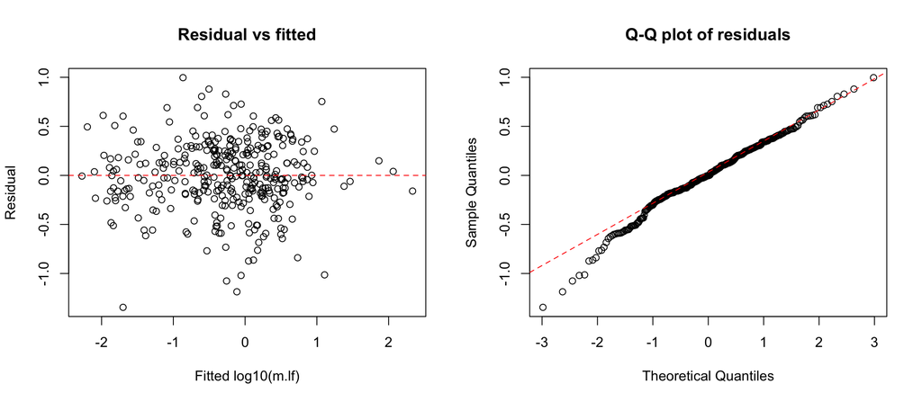

```r
par(mfrow = c(1, 2))
plot(inter_aug$fitted, inter_aug$resid,
     xlab = "Fitted log10(m.lf)", ylab = "Residual",
     main = "Residual vs fitted")
abline(h = 0, col = "red", lty = 2)
qqnorm(inter_aug$resid, main = "Q-Q plot of residuals")
qqline(inter_aug$resid, col = "red", lty = 2)
```

```r
par(mfrow = c(1, 1))
```

```r
lev_tab <- inter_aug %>%
  arrange(desc(cook)) %>%
  select(species, n_individuals, cook, std_resid) %>%
  slice_head(n = 15)

kable(lev_tab, digits = 4, caption = "Top potentially influential species (Cook's distance)")
```

Top potentially influential species (Cook’s distance)

| species | n_individuals | cook | std_resid |
| --- | --- | --- | --- |
| Diospyros kaki | 1 | 0.0919 | -3.8347 |
| Ilex integra | 1 | 0.0499 | -2.8903 |
| Pinus radiata | 36 | 0.0263 | 2.1451 |
| Symplocos coreana | 1 | 0.0254 | 1.7465 |
| Litsea sp. | 1 | 0.0219 | -2.3872 |
| Salix spp. | 10 | 0.0206 | 1.4154 |
| Garcinia penangiana | 1 | 0.0185 | 1.7214 |
| Pinus elliottii | 60 | 0.0180 | 2.8296 |
| Beilschmiedia sp. | 1 | 0.0169 | -3.3670 |
| Symplocos glauca | 7 | 0.0154 | -1.4617 |
| Larix laricina | 7 | 0.0148 | 1.4490 |
| Toxicodendron trichocarpum | 166 | 0.0141 | -1.3767 |
| Piptocarpha rotundifolia | 1 | 0.0133 | -3.0540 |
| Rhododendron obtusum | 1 | 0.0133 | -1.7483 |
| Strychnos pseudoquina | 1 | 0.0129 | -2.8952 |

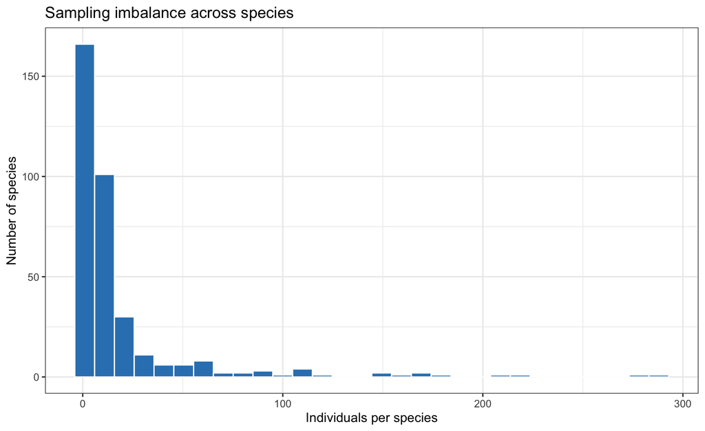

```r
ggplot(species_means, aes(n_individuals)) +
  geom_histogram(bins = 30, fill = "#3182bd", color = "white") +
  scale_x_continuous(labels = comma) +
  labs(
    x = "Individuals per species",
    y = "Number of species",
    title = "Sampling imbalance across species"
  )
```

## 12.1 Caveat Reporting

1. BAAD combines studies with heterogeneous protocols, sites, and taxonomic representation.
2. Many species are sparsely sampled, motivating species-mean primary inference to reduce pseudo-replication.
3. RMA uncertainty can depend on package implementation details; smatr provides preferred CIs, while lmodel2 fallback may omit CIs.
4. The intraspecific threshold (n >= 11 and log10 range >= 0.7) improves slope identifiability but excludes narrow-range species.
5. Family-level slopes can still reflect compositional effects and uneven within-family sampling.
6. Hypothesis tests against beta = 2 are approximate where standard errors are inferred from CIs.

# 13 Reproducibility Metadata

```r
si <- sessionInfo()
print(si$R.version$version.string)
```

```
## [1] "R version 4.6.0 (2026-04-24)"
```

```r
print(si$platform)
```

```
## [1] "aarch64-apple-darwin23"
```

```r
print(c(
  HAS_SMATR = HAS_SMATR,
  HAS_LMODEL2 = HAS_LMODEL2
))
```

```
##   HAS_SMATR HAS_LMODEL2
##        TRUE       FALSE
```

```r
summary_block <- tibble(
  item = c(
    "Records analyzed (positive d.bh and m.lf, with species)",
    "Species in interspecific analysis",
    "Eligible intraspecific species",
    "Eligible families"
  ),
  value = c(
    nrow(analysis_dat),
    nrow(species_means),
    length(eligible_species),
    length(eligible_families)
  )
)

kable(summary_block, caption = "Analysis coverage summary")
```

Analysis coverage summary

| item | value |
| --- | --- |
| Records analyzed (positive d.bh and m.lf, with species) | 6465 |
| Species in interspecific analysis | 351 |
| Eligible intraspecific species | 100 |
| Eligible families | 18 |